# Uso de la API del Covid19 con Pandas

## Comparación

Comparemos estos tres países en un solo gráfico.

Volvemos a seguir los mismos pasos, en un primer lugar creamos un índice con los dos parámetros que queremos que posea nuestro gráfico.

```python
casos_it = df_it.set_index('Date')['Cases']
casos_es = df_es.set_index('Date')['Cases']
casos_mx = df_mx.set_index('Date')['Cases']
```

```python
casos_es
```

```
Date
2020-01-22 00:00:00+00:00           0
2020-01-23 00:00:00+00:00           0
2020-01-24 00:00:00+00:00           0
2020-01-25 00:00:00+00:00           0
2020-01-26 00:00:00+00:00           0
                               ...
2022-03-30 00:00:00+00:00    11508309
2022-03-31 00:00:00+00:00    11508309
2022-04-01 00:00:00+00:00    11551574
2022-04-02 00:00:00+00:00    11551574
2022-04-03 00:00:00+00:00    11551574
Name: Cases, Length: 803, dtype: int64
```

Con la función Pandas concat lo que conseguimos hacer es encadenar datos a lo largo de un eje particular con lógica de conjunto opcional a lo largo de los otros ejes.

También se puede agregar una capa de indexación jerárquica en el eje de concatenación, lo que puede ser útil si las etiquetas son las mismas (o se superponen) en el número de eje pasado.

```python
pd.concat([casos_es,casos_it,casos_mx],axis=1)
```

| Date | Cases | Cases | Cases |
| --- | --- | --- | --- |
| 2020-01-22 00:00:00+00:00 | 0 | 0 | 0 |
| 2020-01-23 00:00:00+00:00 | 0 | 0 | 0 |
| 2020-01-24 00:00:00+00:00 | 0 | 0 | 0 |
| 2020-01-25 00:00:00+00:00 | 0 | 0 | 0 |
| 2020-01-26 00:00:00+00:00 | 0 | 0 | 0 |
| ... | ... | ... | ... |
| 2022-03-30 00:00:00+00:00 | 11508309 | 14567990 | 5654311 |
| 2022-03-31 00:00:00+00:00 | 11508309 | 14642354 | 5659535 |
| 2022-04-01 00:00:00+00:00 | 11551574 | 14719394 | 5662073 |
| 2022-04-02 00:00:00+00:00 | 11551574 | 14790806 | 5665376 |
| 2022-04-03 00:00:00+00:00 | 11551574 | 14845815 | 5666215 |

803 rows × 3 columns

vs es como definimos este Data Frame. Anteriormente se ha concatenado lo que ya hemos, pero si queremos crear algo es necesario poner que algo es igual a algo. Podemos poner versus, comparación... etc.

```python
vs = pd.concat([casos_es,casos_it,casos_mx],axis=1)
vs
```

| Date | Cases | Cases | Cases |
| --- | --- | --- | --- |
| 2020-01-22 00:00:00+00:00 | 0 | 0 | 0 |
| 2020-01-23 00:00:00+00:00 | 0 | 0 | 0 |
| 2020-01-24 00:00:00+00:00 | 0 | 0 | 0 |
| 2020-01-25 00:00:00+00:00 | 0 | 0 | 0 |
| 2020-01-26 00:00:00+00:00 | 0 | 0 | 0 |
| ... | ... | ... | ... |
| 2022-03-30 00:00:00+00:00 | 11508309 | 14567990 | 5654311 |
| 2022-03-31 00:00:00+00:00 | 11508309 | 14642354 | 5659535 |
| 2022-04-01 00:00:00+00:00 | 11551574 | 14719394 | 5662073 |
| 2022-04-02 00:00:00+00:00 | 11551574 | 14790806 | 5665376 |
| 2022-04-03 00:00:00+00:00 | 11551574 | 14845815 | 5666215 |

803 rows × 3 columns

Definimos las columnas que representaremos

```python
vs.columns
```

```
Index(['Cases', 'Cases', 'Cases'], dtype='object')
```

Y definimos los países que hemos escogido

```python
vs.columns = ['España','Italia', 'México']
vs
```

| Date | España | Italia | México |
| --- | --- | --- | --- |
| 2020-01-22 00:00:00+00:00 | 0 | 0 | 0 |
| 2020-01-23 00:00:00+00:00 | 0 | 0 | 0 |
| 2020-01-24 00:00:00+00:00 | 0 | 0 | 0 |
| 2020-01-25 00:00:00+00:00 | 0 | 0 | 0 |
| 2020-01-26 00:00:00+00:00 | 0 | 0 | 0 |
| ... | ... | ... | ... |
| 2022-03-30 00:00:00+00:00 | 11508309 | 14567990 | 5654311 |
| 2022-03-31 00:00:00+00:00 | 11508309 | 14642354 | 5659535 |
| 2022-04-01 00:00:00+00:00 | 11551574 | 14719394 | 5662073 |
| 2022-04-02 00:00:00+00:00 | 11551574 | 14790806 | 5665376 |
| 2022-04-03 00:00:00+00:00 | 11551574 | 14845815 | 5666215 |

803 rows × 3 columns

Añadimos el título a la gráfica

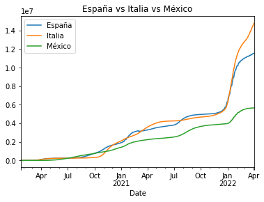

```python
vs.plot(title="España vs Italia vs México")
```

Mediante la función kind=area coloreamos la tabla y rellenamos, como su nombre indica, el área que antes solo se nos indicaba con líneas

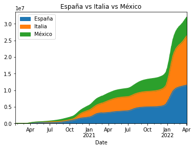

```python
vs.plot(title="España vs Italia vs México", kind='area')
```

## Guardar el progreso

Después procedemos a guardar este gráfico en CVS. Nuestro dataframe que había sido denominado como vs será guardado en nuestro perfil de Jupyter.

```python
vs.to_csv('esvsitvsmx.csv')
```

Con la ! volvemos a indicar que estamos ejecutando Bash y no Phyton y mediante la función ls listamos y vemos si se ha guardado correctamente y dónde se ha guardado.

```python
!ls
```

```
esvsitvsmx.csv			 probando-con-phyton.ipynb  Shared_Resources
phyton-api-covid19-pandas.ipynb  probando-con-r.ipynb	    Untitled.ipynb
```

Previamente, con csv, hemos guardado los datos. Sin embargo, también querríamos guardar la gráfica como imagen. Por tanto, usamos el comando matplotlib, que es una librería que permite visualizar datos en Jupyter y, de ahí, guardamos en png.

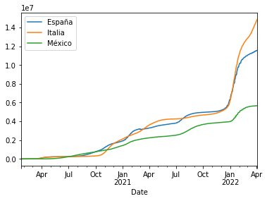

```python
import matplotlib.pyplot as plt
vs.plot()
plt.savefig('esvsitvsmx.png')
```

```python
!ls
```

```
esvsitvsmx.csv			 probando-con-phyton.ipynb  Untitled.ipynb
esvsitvsmx.png			 probando-con-r.ipynb
phyton-api-covid19-pandas.ipynb  Shared_Resources
```

Por último, comprobamos dónde se ha guardado y si hemos ejecutado el último comando correctamente.